# Model Assumptions

Brandon LeBeau

March 6, 2017

I want to spend a little bit of time talking about model assumptions. These are important and should be checked for any analysis. The following packages will be used for this set of notes.

```r
library(modelr)
library(broom)
library(forcats)
library(tidyverse)
```

We are also going to use this model from the advanced model section to explore model assumptions.

```r
heights2 <- heights %>%
  mutate(
    marital_comb = fct_recode(marital,
          'Other' = 'separated',
          'Other' = 'widowed'
    )
  )
afqt_mod <- lm(afqt ~ marital_comb + height, data = heights2)
summary(afqt_mod)
```

```
Call:
lm(formula = afqt ~ marital_comb + height, data = heights2)

Residuals:
    Min      1Q  Median      3Q     Max
-53.150 -22.517  -4.248  22.097  78.355

Coefficients:
                      Estimate Std. Error t value Pr(>|t|)
(Intercept)          -28.99932    5.67144  -5.113 3.25e-07 ***
marital_combmarried   16.13531    0.96385  16.741  < 2e-16 ***
marital_combOther     -4.63978    1.50160  -3.090  0.00201 **
marital_combdivorced   6.75490    1.11278   6.070 1.35e-09 ***
height                 0.89847    0.08329  10.787  < 2e-16 ***
---
Signif. codes:  0 â€˜***â€™ 0.001 â€˜**â€™ 0.01 â€˜*â€™ 0.05 â€˜.â€™ 0.1 â€˜ â€™ 1

Residual standard error: 27.78 on 6739 degrees of freedom
  (262 observations deleted due to missingness)
Multiple R-squared:  0.08467,   Adjusted R-squared:  0.08413
F-statistic: 155.8 on 4 and 6739 DF,  p-value: < 2.2e-16
```

## `plot` function with model object

One of the nicest features when model building within R, is that many diagnostic plots are very accessible using the `plot` function. For example:

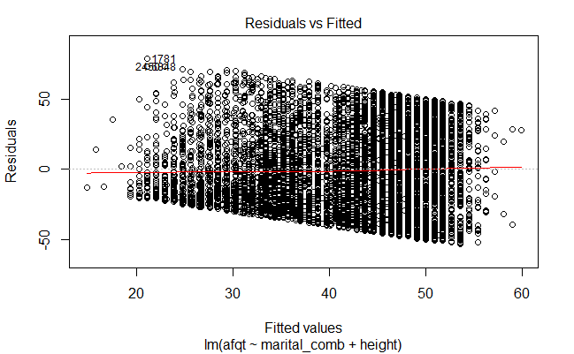

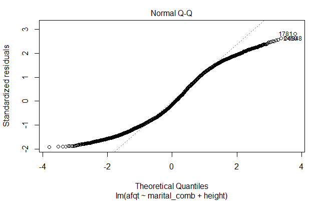

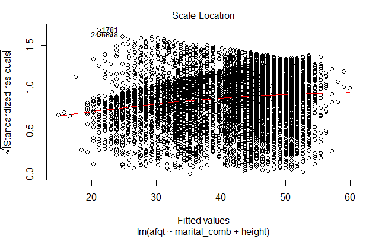

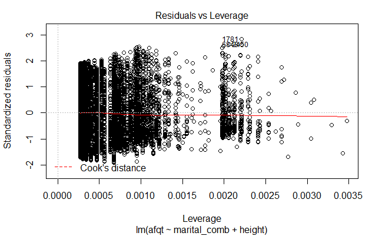

```r
plot(afqt_mod)
```

These plots are shown one at a time in an interactive R session, but allow you to check many common assumptions such as normal residuals, linearity, homogeneity of variance, and even leverage.

Suppose we add some additional variables to the model keeping the model additive. Note, I am also mean centering many of the continuous variables to ease interpretation slightly.

```r
heights2 <- heights2 %>%
  mutate(income2 = ifelse(income == 0, .001, income),
         height2 = height - mean(height, na.rm = TRUE),
         education2 = education - mean(education, na.rm = TRUE),
         weight2 = weight - mean(weight, na.rm = TRUE),
         log_income = log(income2))
afqt_alt <- lm(afqt ~ marital_comb + height2 + education2 +
                 log_income + weight2, data = heights2)
summary(afqt_alt)
```

```
Call:
lm(formula = afqt ~ marital_comb + height2 + education2 + log_income +
    weight2, data = heights2)

Residuals:
    Min      1Q  Median      3Q     Max
-80.466 -16.515  -2.036  16.088 101.730

Coefficients:
                      Estimate Std. Error t value Pr(>|t|)
(Intercept)          32.645765   0.717463  45.502  < 2e-16 ***
marital_combmarried   9.312248   0.802952  11.598  < 2e-16 ***
marital_combOther    -2.537031   1.231340  -2.060   0.0394 *
marital_combdivorced  4.790976   0.913836   5.243 1.63e-07 ***
height2               0.781474   0.077526  10.080  < 2e-16 ***
education2            5.911616   0.111848  52.854  < 2e-16 ***
log_income            0.395176   0.038720  10.206  < 2e-16 ***
weight2              -0.027669   0.007074  -3.911 9.27e-05 ***
---
Signif. codes:  0 â€˜***â€™ 0.001 â€˜**â€™ 0.01 â€˜*â€™ 0.05 â€˜.â€™ 0.1 â€˜ â€™ 1

Residual standard error: 22.57 on 6637 degrees of freedom
  (361 observations deleted due to missingness)
Multiple R-squared:  0.3969,    Adjusted R-squared:  0.3963
F-statistic:   624 on 7 and 6637 DF,  p-value: < 2.2e-16
```

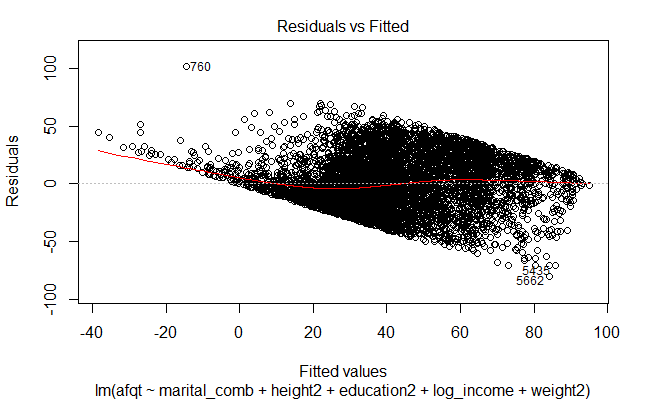

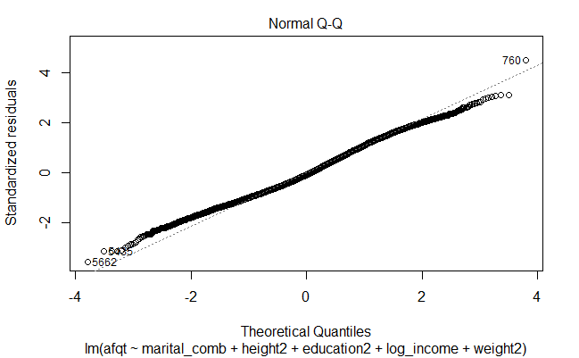

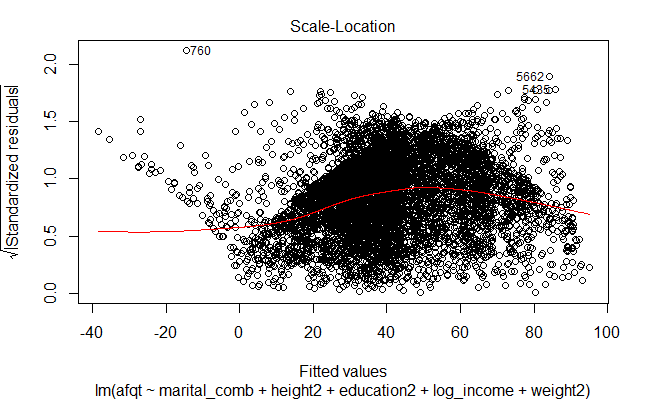

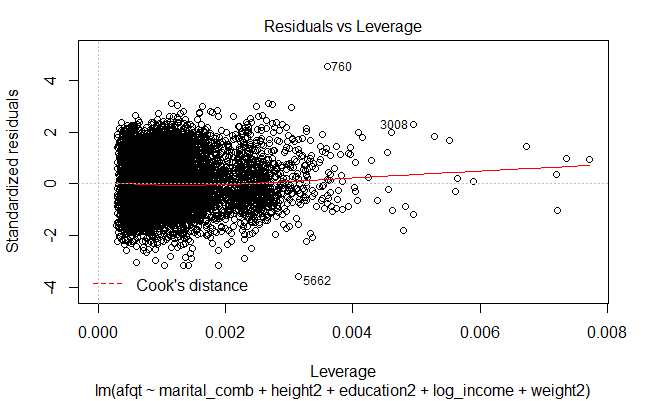

```r
plot(afqt_alt)
```

We could continue to model this variable by including additional predictors or interactions between our current predictors to attempt to remove this strong trend in the residuals. I’m going to stop here however and move on to another topic.

## Exploring individual residuals

Evaluating all of the residuals in a single step using the `plot` function can be useful initially to explore model quality. However, eventually it is useful to explore residuals for specific values to explore why these are large.

There are a few options to do this, one uses the broom package, the other uses the modelr package. I show both below.

```r
aug_afqt <- augment(afqt_alt)
aug_afqt
```

| .rownames | afqt | marital_comb | height2 | education2 | log_income | weight2 | .fitted | .se.fit | .resid | .hat | .sigma | .cooksd | .std.resid |
| --- | --- | --- | --- | --- | --- | --- | --- | --- | --- | --- | --- | --- | --- |
| 1 | 6.841 | married | -7.1043391 | -0.2181246 | 9.852194 | -33.3040081 | 39.9315172 | 0.6462020 | -33.090517208 | 0.0008197572 | 22.56774 | 2.206294e-04 | -1.4667495967 |
| 2 | 49.444 | married | 2.8956609 | -3.2181246 | 10.463103 | -32.3040081 | 30.2251572 | 0.7105733 | 19.218842849 | 0.0009912118 | 22.57016 | 9.002042e-05 | 0.8519555225 |
| 3 | 99.393 | married | -2.1043391 | 2.7818754 | 11.561716 | 6.6959919 | 61.1425522 | 0.5206693 | 38.250447776 | 0.0005321972 | 22.56651 | 1.912788e-04 | 1.6952215347 |
| 4 | 44.022 | married | -4.1043391 | 0.7818754 | 10.596635 | 8.6959919 | 47.3196592 | 0.5476115 | -3.297659188 | 0.0005886996 | 22.57136 | 1.572807e-06 | -0.1461530836 |
| 5 | 59.683 | married | -1.1043391 | 0.7818754 | 11.225243 | 1.6959919 | 50.1061720 | 0.4197570 | 9.576827995 | 0.0003458953 | 22.57109 | 7.790175e-06 | 0.4243958727 |
| 6 | 98.798 | divorced | 0.8956609 | 4.7818754 | 11.532728 | 11.6959919 | 70.6391347 | 0.8187257 | 28.158865292 | 0.0013159081 | 22.56874 | 2.567192e-04 | 1.2484622797 |
| 7 | 82.260 | married | 6.8956609 | 2.7818754 | -6.907755 | 36.6959919 | 60.0470618 | 0.9139984 | 22.212938241 | 0.0016399839 | 22.56974 | 1.992214e-04 | 0.9850012023 |
| 8 | 50.283 | divorced | -3.1043391 | -1.2181246 | 11.156251 | -28.3040081 | 33.0015142 | 0.6798331 | 17.281485757 | 0.0009073050 | 22.57040 | 6.661355e-05 | 0.7660419042 |
| 9 | 89.669 | divorced | 1.8956609 | -1.2181246 | 11.002100 | -26.3040081 | 36.7926296 | 0.7016303 | 52.876370440 | 0.0009664187 | 22.56205 | 6.643350e-04 | 2.3439369983 |
| 10 | 95.977 | divorced | 1.8956609 | -0.2181246 | 11.918391 | 5.6959919 | 42.1809470 | 0.6504959 | 53.796053022 | 0.0008306877 | 22.56172 | 5.909070e-04 | 2.3845432868 |

[output cut: 990 more lines]

```r
height_resid <- heights2 %>%
  add_residuals(afqt_alt) %>%
  add_predictions(afqt_alt)
height_resid
```

| income | height | weight | age | marital | sex | education | afqt | marital_comb | income2 | height2 | education2 | weight2 | log_income | resid | pred |
| --- | --- | --- | --- | --- | --- | --- | --- | --- | --- | --- | --- | --- | --- | --- | --- |
| 19000 | 60 | 155 | 53 | married | female | 13 | 6.841 | married | 19000.000 | -7.1043391 | -0.2181246 | -33.3040081 | 9.852194 | -33.090517208 | 39.9315172 |
| 35000 | 70 | 156 | 51 | married | female | 10 | 49.444 | married | 35000.000 | 2.8956609 | -3.2181246 | -32.3040081 | 10.463103 | 19.218842849 | 30.2251572 |
| 105000 | 65 | 195 | 52 | married | male | 16 | 99.393 | married | 105000.000 | -2.1043391 | 2.7818754 | 6.6959919 | 11.561716 | 38.250447776 | 61.1425522 |
| 40000 | 63 | 197 | 54 | married | female | 14 | 44.022 | married | 40000.000 | -4.1043391 | 0.7818754 | 8.6959919 | 10.596635 | -3.297659188 | 47.3196592 |
| 75000 | 66 | 190 | 49 | married | male | 14 | 59.683 | married | 75000.000 | -1.1043391 | 0.7818754 | 1.6959919 | 11.225243 | 9.576827995 | 50.1061720 |
| 102000 | 68 | 200 | 49 | divorced | female | 18 | 98.798 | divorced | 102000.000 | 0.8956609 | 4.7818754 | 11.6959919 | 11.532728 | 28.158865292 | 70.6391347 |
| 0 | 74 | 225 | 48 | married | male | 16 | 82.260 | married | 0.001 | 6.8956609 | 2.7818754 | 36.6959919 | -6.907755 | 22.212938241 | 60.0470618 |
| 70000 | 64 | 160 | 54 | divorced | female | 12 | 50.283 | divorced | 70000.000 | -3.1043391 | -1.2181246 | -28.3040081 | 11.156251 | 17.281485757 | 33.0015142 |
| 60000 | 69 | 162 | 55 | divorced | male | 12 | 89.669 | divorced | 60000.000 | 1.8956609 | -1.2181246 | -26.3040081 | 11.002100 | 52.876370440 | 36.7926296 |
| 150000 | 69 | 194 | 54 | divorced | male | 13 | 95.977 | divorced | 150000.000 | 1.8956609 | -0.2181246 | 5.6959919 | 11.918391 | 53.796053022 | 42.1809470 |

[output cut: 990 more lines]

The benefit to the `augment` function from the broom package is that it includes more information. The main benefit fo the `add_residuals` function from the modelr pacakge is that it includes all of the original data, not just those variables included in the final model. Therefore if you are fitting a model and want to explore trends in residuals based on other data characteristics not currently in the model, using the `add_residuals` function would likely be better for this use.

### Filtering and Plotting Residuals

Now that we have these in a data frame, we could easily plot or filter residuals to explore cases in which the model is not adequatly fitting the dependent variable. For example, maybe we want to explore residuals greater than 50 in absolute value. This can easily be done with dplyr and the `filter` function.

```r
filter(height_resid, abs(resid) > 50)
```

| income | height | weight | age | marital | sex | education | afqt | marital_comb | income2 | height2 | education2 | weight2 | log_income | resid | pred |
| --- | --- | --- | --- | --- | --- | --- | --- | --- | --- | --- | --- | --- | --- | --- | --- |
| 60000 | 69 | 162 | 55 | divorced | male | 12 | 89.669 | divorced | 60000.000 | 1.8956609 | -1.2181246 | -26.3040081 | 11.002100 | 52.87637 | 36.792630 |
| 150000 | 69 | 194 | 54 | divorced | male | 13 | 95.977 | divorced | 150000.000 | 1.8956609 | -0.2181246 | 5.6959919 | 11.918391 | 53.79605 | 42.180947 |
| 45000 | 69 | 240 | 53 | married | male | 12 | 98.841 | married | 45000.000 | 1.8956609 | -1.2181246 | 51.6959919 | 10.714418 | 59.79893 | 39.042067 |
| 0 | 66 | 195 | 50 | married | female | 14 | 99.150 | married | 0.001 | -1.1043391 | 0.7818754 | 6.6959919 | -6.907755 | 56.34790 | 42.802097 |
| 93000 | 68 | 182 | 48 | divorced | male | 12 | 86.932 | divorced | 93000.000 | 0.8956609 | -1.2181246 | -6.3040081 | 11.440355 | 51.30103 | 35.630972 |
| 43000 | 64 | 145 | 51 | divorced | female | 12 | 94.821 | divorced | 43000.000 | -3.1043391 | -1.2181246 | -43.3040081 | 10.668955 | 61.59702 | 33.223975 |
| 52000 | 72 | 230 | 52 | married | male | 12 | 93.142 | married | 52000.000 | 4.8956609 | -1.2181246 | 41.6959919 | 10.858999 | 51.42169 | 41.720310 |
| 35000 | 59 | 165 | 49 | divorced | female | 12 | 79.950 | divorced | 35000.000 | -8.1043391 | -1.2181246 | -23.3040081 | 10.463103 | 51.26811 | 28.681887 |
| 85000 | 61 | 140 | 55 | married | female | 18 | 15.699 | married | 85000.000 | -6.1043391 | 4.7818754 | -48.3040081 | 11.350407 | -55.57916 | 71.278155 |
| 0 | 69 | 186 | 55 | separated | female | 12 | 88.779 | Other | 0.001 | 1.8956609 | -1.2181246 | -2.3040081 | -6.907755 | 67.05597 | 21.723026 |

[output cut: 103 more lines]

You can also plot residuals directly or compared to other predictors.

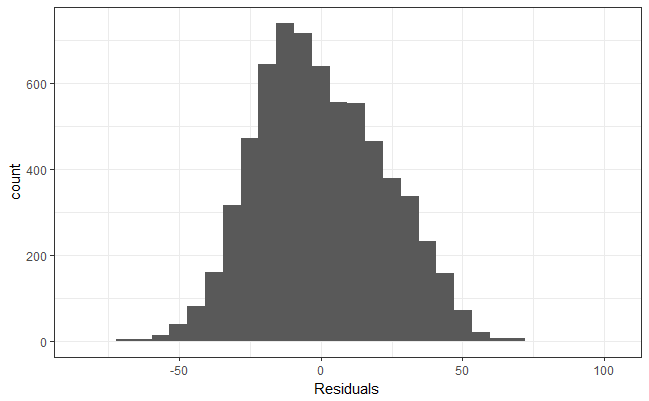

```r
ggplot(height_resid, aes(resid)) +
  geom_histogram() +
  theme_bw() +
  xlab("Residuals")
```

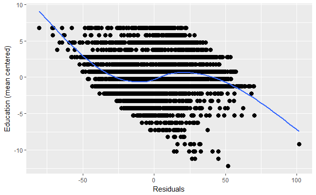

```r
ggplot(height_resid, aes(resid, education2)) +
  geom_point(size = 3) +
  geom_smooth(size = 1, se = FALSE) +
  xlab("Residuals") +
  ylab("Education (mean centered)")
```